# chapter 2: Regression and model validation

## Fit a regression model

```r
lm.1 <- lm(points~attitude+deep+stra, data = df)
summary(lm.1)
```

```
##
## Call:
## lm(formula = points ~ attitude + deep + stra, data = df)
##
## Residuals:
##      Min       1Q   Median       3Q      Max
## -17.5239  -3.4276   0.5474   3.8220  11.5112
##
## Coefficients:
##             Estimate Std. Error t value Pr(>|t|)
## (Intercept)  11.3915     3.4077   3.343  0.00103 **
## attitude      3.5254     0.5683   6.203 4.44e-09 ***
## deep         -0.7492     0.7507  -0.998  0.31974
## stra          0.9621     0.5367   1.793  0.07489 .
## ---
## Signif. codes:  0 '***' 0.001 '**' 0.01 '*' 0.05 '.' 0.1 ' ' 1
##
## Residual standard error: 5.289 on 162 degrees of freedom
## Multiple R-squared:  0.2097, Adjusted R-squared:  0.195
## F-statistic: 14.33 on 3 and 162 DF,  p-value: 2.521e-08
```

```r
lm.2 <- lm(points~attitude, data = df)
summary(lm.2)
```

```
##
## Call:
## lm(formula = points ~ attitude, data = df)
##
## Residuals:
##      Min       1Q   Median       3Q      Max
## -16.9763  -3.2119   0.4339   4.1534  10.6645
##
## Coefficients:
##             Estimate Std. Error t value Pr(>|t|)
## (Intercept)  11.6372     1.8303   6.358 1.95e-09 ***
## attitude      3.5255     0.5674   6.214 4.12e-09 ***
## ---
## Signif. codes:  0 '***' 0.001 '**' 0.01 '*' 0.05 '.' 0.1 ' ' 1
##
## Residual standard error: 5.32 on 164 degrees of freedom
## Multiple R-squared:  0.1906, Adjusted R-squared:  0.1856
## F-statistic: 38.61 on 1 and 164 DF,  p-value: 4.119e-09
```

## Explanations on the fitted model

R-squareds tell how large proportion of the variance in Y the line explains compared to the total variance in Y .

```r
summary(lm.2)$r.squared
```

```
## [1] 0.1905537
```

In this case, the linear model on attitude explains around 20% of the variation in exam points and therefore leaves about 80% of variation in exam points as something that cannot be explained by (a linear effect of) attitude only.

## Produce the following diagnostic plots

### Residuals vs Fitted values, Normal QQ-plot and Residuals vs Leverage

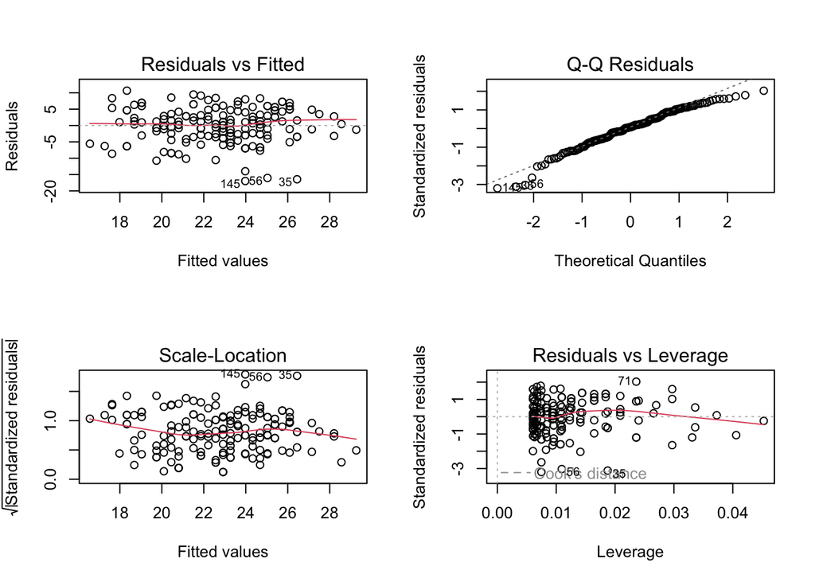

```r
par(mfrow = c(2,2))
plot(lm.2)
```

1. Residuals vs. fitted should not show a pattern where the distribution of residuals varies depending on the fitted values. Thus, is is good if the red line showing the mean of data points is close to a horizontal line.
2. QQ-plot should ideally be on the diagonal line, in which case the residuals are Normally distributed and SEs and P-values of the model coefficients are reliable. In this case, the QQ-plot deviated from the diagonal line.
3. Residuals vs. leverage should not show points that reach outside the curved areas of Cook’s distance 1. Otherwise, such points would have a high influence on the slope of the linear model, and hence the lm() estimates from such data would not be reliable.